# Coding Assignment 1

Team 9

Due: 2024-09-22 23:59

```r
# Put any packages you want here

library(gt)
library(plotly)
library(readxl)
library(corrplot)
library(car)
library(ggplot2)
library(jtools)
library(sos)
library(magrittr)
library(tidyverse)
library(gtsummary)
library(knitr)
library(parameters)
library(broom.helpers)
```

A Florida health insurance company wants to predict annual claims for individual clients. The company pulls a random sample of 100 customers. The owner wishes to charge an actuarially fair premium to ensure a normal rate of return. The owner collects all of their current customer’s health care expenses from the last year and compares them with what is known about each customer’s plan.

The data on the 100 customers in the sample is as follows:

- Charges: Total medical expenses for a particular insurance plan (in dollars)
- Age: Age of the primary beneficiary
- BMI: Primary beneficiary’s body mass index (kg/m2)
- Female: Primary beneficiary’s birth sex (0 = Male, 1 = Female)
- Children: Number of children covered by health insurance plan (includes other dependents as well)
- Smoker: Indicator if primary beneficiary is a smoker (0 = non-smoker, 1 = smoker)
- Cities: Dummy variables for each city with the default being Sanford

Answer the following questions using complete sentences and attach all output, plots, etc. within this report.

**For this assignment, ignore the categorical variables (gender, smoker, cities)**

# Question 1

Perform univariate analyses on the quantitative variables (center, shape, spread). Include descriptive statistics, and histograms. Be sure to use terms discussed in class such as bimodal, skewed left, etc.

```r
mean(Insurance_Data_Group9$Charges)
```

```
## [1] 13494.13
```

```r
median(Insurance_Data_Group9$Charges)
```

```
## [1] 8964.928
```

```r
getModes <- function(x) {
  ux <- unique(x)
  tab <- tabulate(match(x, ux))
  ux[tab == max(tab)]
}
getModes(Insurance_Data_Group9$Charges)
```

```
##   [1]  7742.110  2026.974  2196.473 40720.551  9877.608 11987.168  4544.235
##   [8] 12797.210  1986.933  2007.945 10370.913 19442.354  8965.796  9910.360
##  [15] 17043.341  2134.901 12731.000  2483.736  7418.522  1694.796 18246.496
##  [22] 19350.369 21098.554  5920.104  6610.110  6548.195 18033.968  8232.639
##  [29]  6185.321 16069.085 42760.502  8520.026  6123.569 48885.136  7789.635
##  [36] 33475.817  2154.361 51194.559  1263.249 42112.236 10807.486  5003.853
##  [43]  8233.097 21195.818 46718.163 46130.526  7337.748  3268.847 16577.780
##  [50] 15161.534 14394.558  8671.191 19515.542  3046.062 10977.206 11356.661
##  [57] 35491.640 20149.323  1136.399  4347.023 13887.204  1646.430  1917.318
##  [64]  1725.552  4877.981 12124.992  9391.346  7348.142  7749.156  3309.793
##  [71]  5245.227 14007.222  9282.481  7731.427 15230.324 42856.838  1815.876
##  [78] 40273.645  7729.646  7726.854  2322.622 12222.898  8116.680 19521.968
##  [85] 39125.332 12485.801  1252.407 22462.044 38709.176  9748.911  4931.647
##  [92]  2566.471  6117.494 17081.080  8964.061  8615.300 28340.189  9432.925
##  [99]  5257.508  8083.920
```

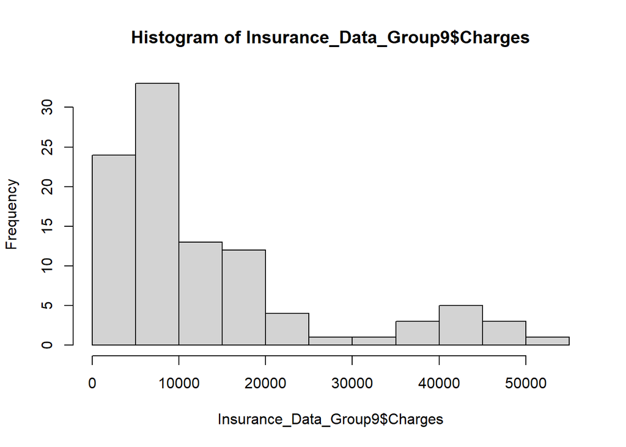

```r
hist(Insurance_Data_Group9$Charges)
```

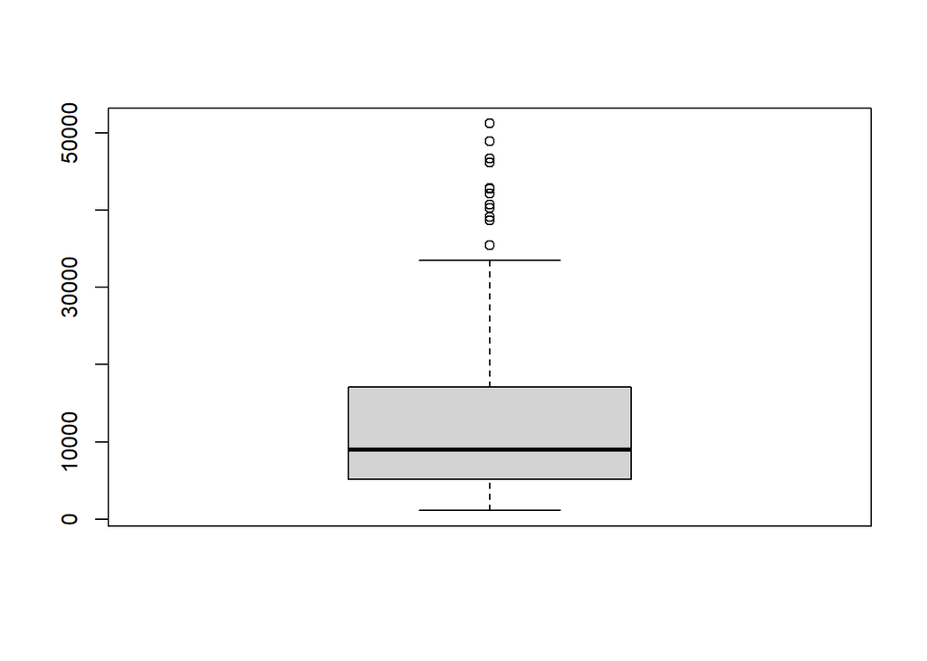

```r
boxplot(Insurance_Data_Group9$Charges)
```

```r
var(Insurance_Data_Group9$Charges)
```

```
## [1] 159740749
```

```r
sd(Insurance_Data_Group9$Charges)
```

```
## [1] 12638.86
```

```r
IQR(Insurance_Data_Group9$Charges)
```

```
## [1] 11867.89
```

```r
range(Insurance_Data_Group9$Charges)
```

```
## [1]  1136.399 51194.559
```

**Considering the mean (13494.13) is greater than the median (8964.928), the data for charges is skewed right. The data is multimodal, owing to a plethora of modes found within this data.**

```r
mean(Insurance_Data_Group9$Age)
```

```
## [1] 39.12
```

```r
median(Insurance_Data_Group9$Age)
```

```
## [1] 40.5
```

```r
getModes <- function(x) {
  ux <- unique(x)
  tab <- tabulate(match(x, ux))
  ux[tab == max(tab)]
}
getModes(Insurance_Data_Group9$Age)
```

```
## [1] 39 45
```

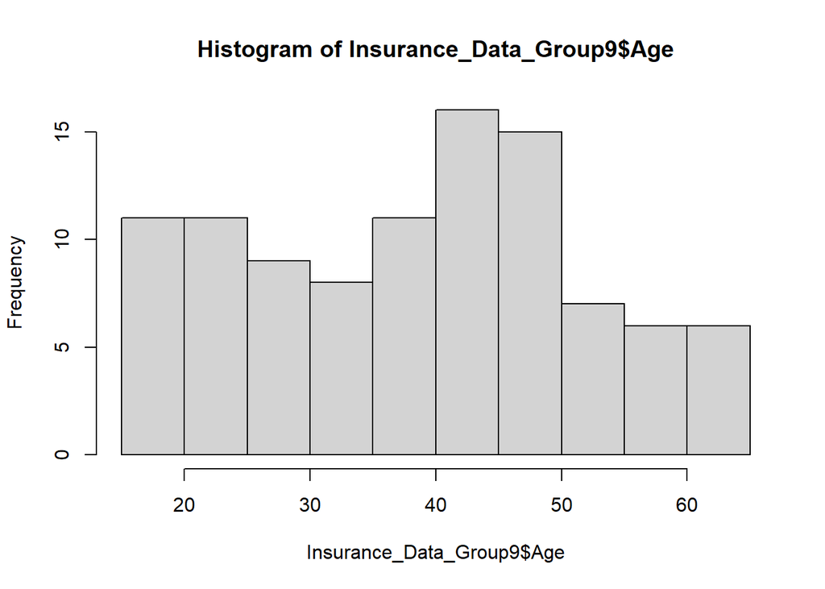

```r
hist(Insurance_Data_Group9$Age)
```

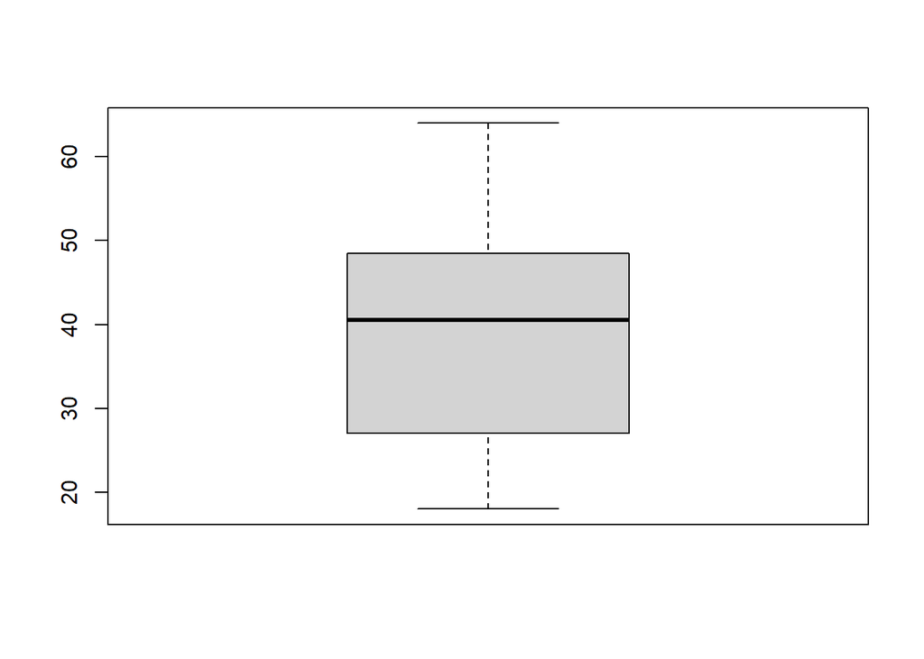

```r
boxplot(Insurance_Data_Group9$Age)
```

```r
var(Insurance_Data_Group9$Age)
```

```
## [1] 178.3491
```

```r
sd(Insurance_Data_Group9$Age)
```

```
## [1] 13.35474
```

```r
IQR(Insurance_Data_Group9$Age)
```

```
## [1] 21.25
```

```r
range(Insurance_Data_Group9$Age)
```

```
## [1] 18 64
```

```r
mean(Insurance_Data_Group9$BMI)
```

```
## [1] 31.34375
```

```r
median(Insurance_Data_Group9$BMI)
```

```
## [1] 30.8375
```

```r
getModes <- function(x) {
  ux <- unique(x)
  tab <- tabulate(match(x, ux))
  ux[tab == max(tab)]
}
getModes(Insurance_Data_Group9$BMI)
```

```
## [1] 36.480 33.345 27.500 33.660 26.410 25.840
```

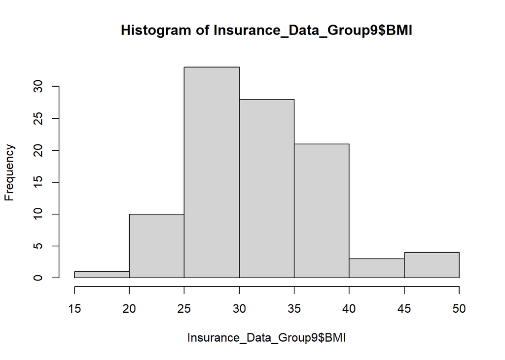

```r
hist(Insurance_Data_Group9$BMI)
```

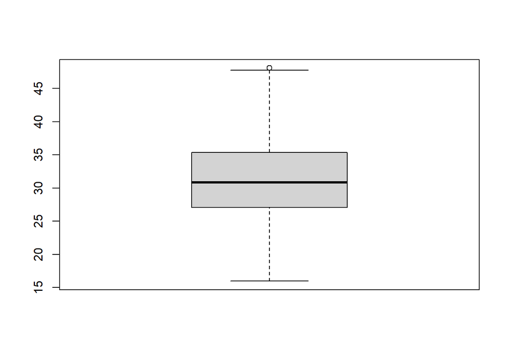

```r
boxplot(Insurance_Data_Group9$BMI)
```

```r
var(Insurance_Data_Group9$BMI)
```

```
## [1] 35.11825
```

```r
sd(Insurance_Data_Group9$BMI)
```

```
## [1] 5.926065
```

```r
IQR(Insurance_Data_Group9$BMI)
```

```
## [1] 8.235
```

```r
range(Insurance_Data_Group9$BMI)
```

```
## [1] 15.96 48.07
```

**The data for BMI is slightly skewed to the right due to the fact that mean (31.34375) is greater than the median (30.8375); though slightly skewed, the mean and median are nearly equal. The univariate analysis on BMI indicates that the data is multimodal. The modes are as follows: 36.480, 33.345, 27.500, 33.660, 26.410, and 25.840.**

```r
mean(Insurance_Data_Group9$Children)
```

```
## [1] 1.03
```

```r
median(Insurance_Data_Group9$Children)
```

```
## [1] 1
```

```r
getModes <- function(x) {
  ux <- unique(x)
  tab <- tabulate(match(x, ux))
  ux[tab == max(tab)]
}
getModes(Insurance_Data_Group9$Children)
```

```
## [1] 0
```

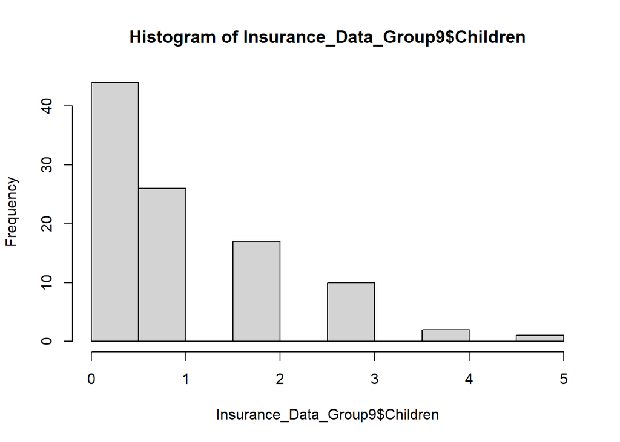

```r
hist(Insurance_Data_Group9$Children)
```

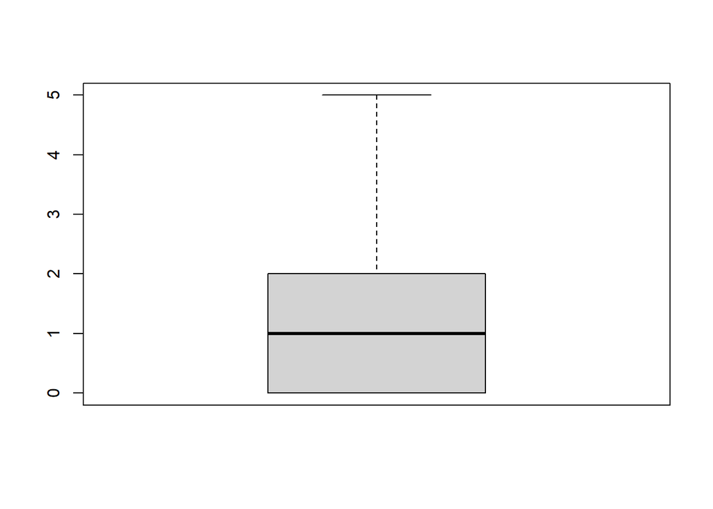

```r
boxplot(Insurance_Data_Group9$Children)
```

```r
var(Insurance_Data_Group9$Children)
```

```
## [1] 1.362727
```

```r
sd(Insurance_Data_Group9$Children)
```

```
## [1] 1.167359
```

```r
IQR(Insurance_Data_Group9$Children)
```

```
## [1] 2
```

```r
range(Insurance_Data_Group9$Children)
```

```
## [1] 0 5
```

# Question 2

Perform bivariate analyses on the quantitative variables (direction, strength and form). Describe the linear association between all variables.

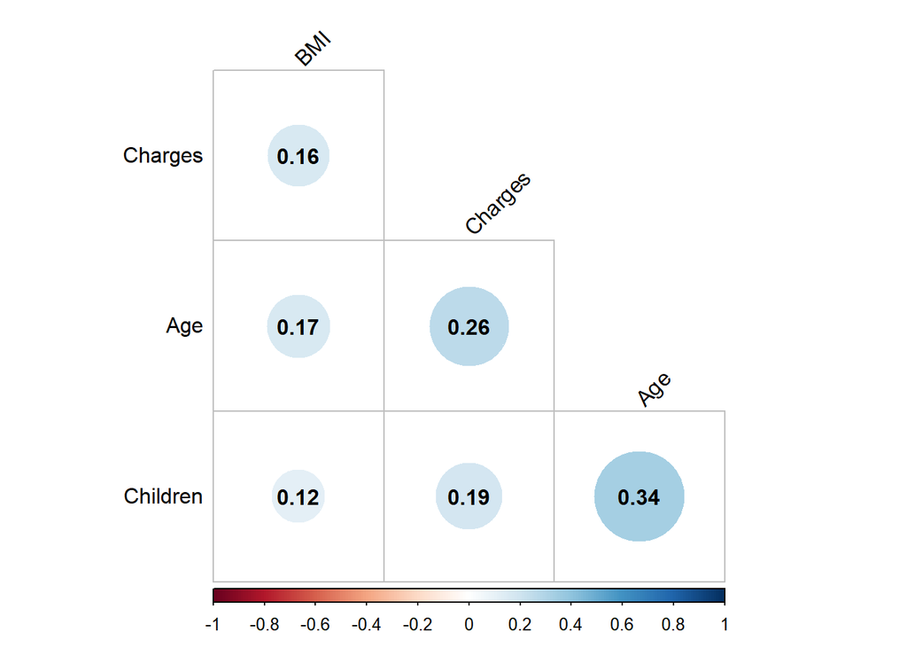

```r
reduced <- Insurance_Data_Group9 %>%
  select(Charges, Age, BMI, Children)

corrplot(cor(reduced),
         type = "lower",
         order = "hclust",
         tl.col = "black",
         tl.srt = 45,
         addCoef.col = "black",
         diag = FALSE)
```

**These are weakly and moderately positively correlated. We might say that BMI has a weak positive relationship with charges, age, and children (correlation is 0.16, 0.17, and 0.12, respectively). A relationship between children and charges is also weakly positive (correlation is 0.19). Age has a moderate positive relationship with charges and children (correlation is 0.26 and 0.34, respectively).**

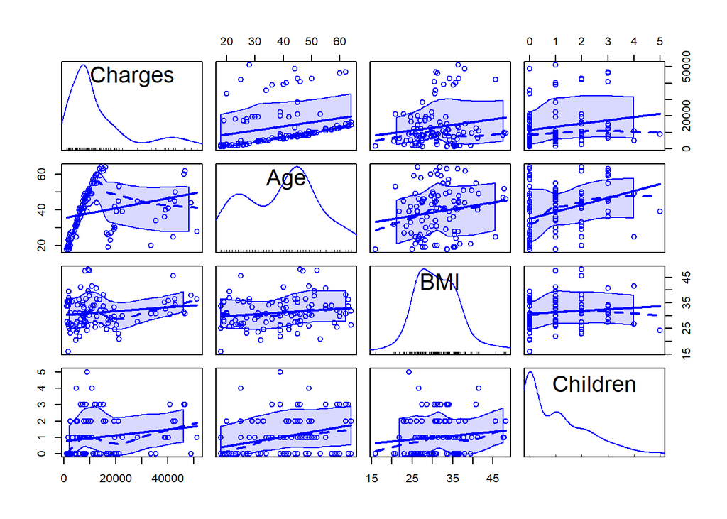

```r
scatterplotMatrix(~ Charges + Age + BMI + Children, data = Insurance_Data_Group9)
```

**Charges vs Age:** The plot shows a positive relationship between Charges and Age, with an upward trend. Generally, the scatter plot shows a moderate positive linear relationship between Age and Charges. As Age increases, Charges tend to increase as well, but the relationship is not perfectly linear due to the presence of outliers and high variability in Charges, especially for older individuals. The outliers in this scatter plot weaken the relationship between Age and Charges.

**Charges vs BMI:** The scatter plot does not follow a linear pattern. There seems to be some general clustering of points, they are spread across the plot, particularly in the lower half. There are several outliers, particularly towards the top right, where BMI and Charges are both high.

**Charges vs Children:** The data points are grouped vertically at distinct values for the number of children (0, 1, 2, etc.,).The scatter plot shows neither a linear nor a non-linear association. It may be noticed that slight increases in Charges as Children increase, although the pattern is not strong. At each level of “Children” (0, 1, 2, etc.), the majority of data points cluster in the lower range of charges (below 15,000), but there are some points much higher, reaching up to 50,000. These higher values represent outliers, as they deviate significantly from the rest of the data. These outliers weaken the association between Charges and Children.

**Age vs BMI:** This scatter plot shows no linear relationship between BMI and Age. The points are spread out relatively evenly across the different age ranges, and no obvious upward or downward trend. The points are widely spread, suggesting that Age and BMI may not be strongly related. While there are a few noticeable outliers, their overall impact on the weak correlation between BMI and Age in this scatter plot is minimal.

**BMI vs Children:** No linear or non-linear relationship between BMI and Children is evident. The scatter suggests that these variables are likely unrelated. The values of “Children” (0 to 5) are distributed somewhat uniformly across the BMI range, from 15 to 45. A few points at the far right (BMI between 40 and 45) may be considered outliers. The points where the number of children is 4 or 5 are also outliers.

# Question 3

Generate a regression equation in the following form:

$$Charges =
\beta_{0}+\beta_{1}*Age+\beta_{2}*BMI+\beta_{3}*Children$$

```r
model <- lm( Charges ~ Age + BMI + Children, data = Insurance_Data_Group9)

summ(model)
```

```
## MODEL INFO:
## Observations: 100
## Dependent Variable: Charges
## Type: OLS linear regression
##
## MODEL FIT:
## F(3,96) = 3.28, p = 0.02
## R² = 0.09
## Adj. R² = 0.06
##
## Standard errors:OLS
## ------------------------------------------------------
##                         Est.      S.E.   t val.      p
## ----------------- ---------- --------- -------- ------
## (Intercept)         -3055.73   7103.38    -0.43   0.67
## Age                   199.54     98.75     2.02   0.05
## BMI                   242.86    210.73     1.15   0.25
## Children             1098.55   1121.30     0.98   0.33
## ------------------------------------------------------
```

**By generating a linear model of the imported data, we can obtain and evaluate the data in terms of a multiple regression formula. The output gives us the intercept in addition to coefficients for age, BMI, and children.**

also write out the regression cleanly in this document.

$$Charges = -3055.73 + 199.54 Age + 242.86
BMI + 1098.55 Children$$

# Question 4

An eager insurance representative comes back with a potential client. The client is 40, their BMI is 30, and they have one dependent. Using the regression equation above, predict the amount of medical expenses associated with this policy. (Provide a 95% confidence interval as well)

```r
newPrediction <- data.frame(Age = 40,
                            BMI = 30,
                            Children = 1)

##this part is the confidence interval calculation

predict(model, newdata = newPrediction)
```

```
##        1
## 13310.43
```

```r
predict(model,
newdata = newPrediction,
interval = "confidence",
level = .95)
```

```
##        fit      lwr      upr
## 1 13310.43 10807.13 15813.72
```

**Using the model from question 3, we can create a new prediction that factors in the given metrics for age, BMI, and children. As such, the new prediction yields a result. The resulting charges given the above data would be $13,310.43.**